# assignment04

Yiwen Wang & Rongrong Sun

2/25/2022

```r
library(tidyverse)
```

```r
library(ggplot2)
Drug_Mortality <- read.csv("Drug Mortality.csv")
```

[Data source](https://data.cdc.gov/NCHS/NCHS-Drug-Poisoning-Mortality-by-State-United-Stat/xbxb-epbu)

#This dataset describes drug poisoning deaths at the state level by selected demographic characteristics and includes age-adjusted mortality rates for drug poisoning from 1999 to 2016. Data are collected from people with all ages, all genders, and all race/origins in the United States.

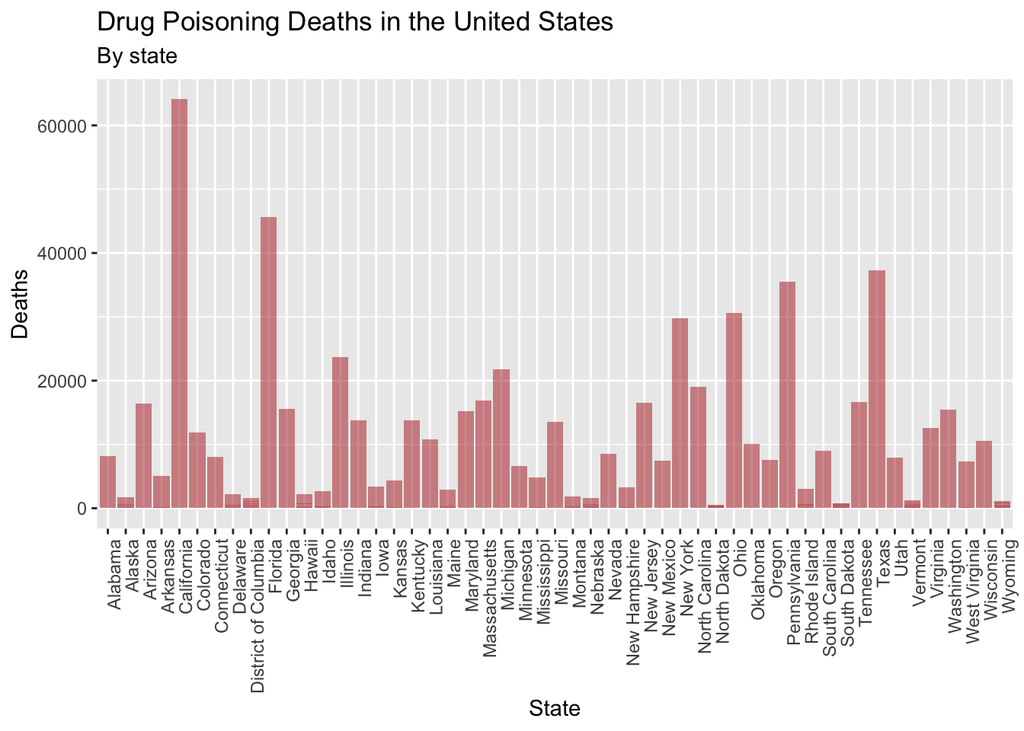

```r
Drug_Mortality %>%
  ggplot() +
  geom_bar(aes(x = State,  y = Deaths),
           stat = "identity",
           fill = "firebrick",
           alpha = 0.5    )+
  labs(
    title = "Drug Poisoning Deaths in the United States",
    subtitle = "By state",
    x = "State",
    y = "Deaths"
  )+
  theme(axis.text.x = element_text(angle = 90, hjust = 1))
```

#Picture1

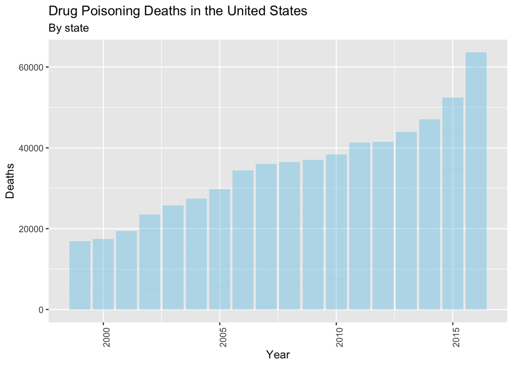

```r
Drug_Mortality %>%
  ggplot() +
  geom_bar(aes(x = Year,  y = Deaths),
           stat = "identity",
           fill = "skyblue",
           alpha = 0.5    )+
  labs(
    title = "Drug Poisoning Deaths in the United States",
    subtitle = "By state",
    x = "Year",
    y = "Deaths"
  )+
  theme(axis.text.x = element_text(angle = 90, hjust = 1))
```

#Picture2

This graph shows the total number of drug-related deaths in all states from 1999 to 2016. The graph shows that the number of drug-related deaths nationwide has increased by tens of years, and the rate of drug deaths has become higher. According to the literature we have collected, drug abuse has become a national problem across urban and rural areas, and the rate of increase in drug abuse deaths has accelerated considerably compared to other causes of death.

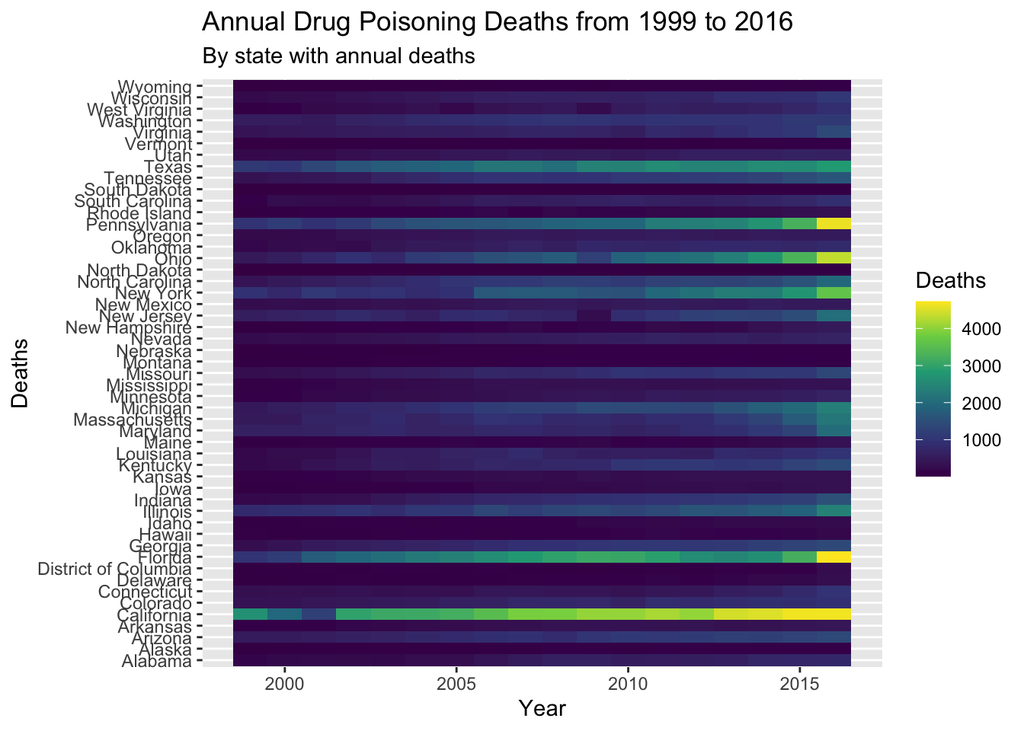

```r
p <- ggplot(data = Drug_Mortality, mapping = aes(
  x = Year, y = State, fill = Deaths))
p + geom_tile() +
  scale_fill_viridis_c()+
  labs(
    title = "Annual Drug Poisoning Deaths from 1999 to 2016",
    subtitle = "By state with annual deaths",
    x = "Year",
    y = "Deaths"
  )
```

#Picture 3

This graph shows the number of deaths and the total cumulative number of deaths in each of the fifty-one U.S. states from 1999 to 2016. According to the picture, different colors represent different numbers of deaths, with lighter colors indicating more deaths in the year and darker colors indicating fewer deaths in the year.

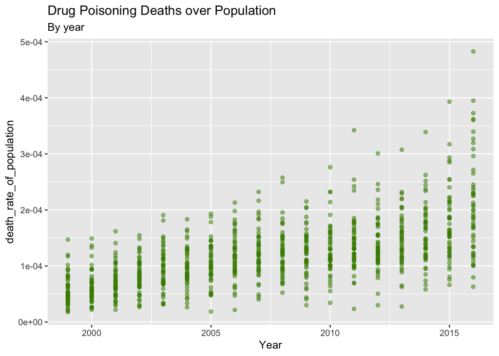

```r
new <- mutate(.data=Drug_Mortality, death_rate_of_population= Deaths/Population)

new %>%
  ggplot(aes(Year, death_rate_of_population))+
  geom_point(color="chartreuse4",
         alpha=0.5)+
  labs(
    title = "Drug Poisoning Deaths over Population",
    subtitle = "By year",
    x = "Year",
    y = "death_rate_of_population"
  )
```

#Picture 4

This graph shows the death rate (deaths/population) for each year from 1999 to 2016. According to the graph, the death rate was the highest in 2016. Drug deaths in the United States are soaring at an unprecedented rate, causing more than 60,000 deaths in 2016 alone, according to information we’ve gathered. Deputy U.S. Attorney General Rod Rosenstein says drug overdoses are now the leading cause of death for Americans under the age of 50. More than 2 million Americans have some kind of physical dependence on opioids. The painkiller is legal to use in some people’s prescriptions, but if patients take too much or for too long, they can become addicted.